# st_crop() without tears

Vanquishing the “attribute variables are assumed to be spatially constant throughout all geometries” warnings

Susannah Cowtan

08/02/2022

# Cropping a map to a box larger than the data suggest

I’m plotting presence records on a coastline map. If I crop the map directly to a box around the data, made using `st_bbox()`, then for those points which are at the edge, it is a matter of luck whether I can see if they are on the coastline or not. This doesn’t work for me; I need to crop the map slightly bigger.

There is also a warning generated when you crop a map geometry which has been generated using `rnaturalearth{}`: “attribute variables are assumed to be spatially constant throughout all geometries”. Warnings offend me. I want to get rid of them, and not by putting `warning = FALSE` in my chunk header. So, here goes.

```r
library(ggplot2)
suppressPackageStartupMessages(library(dplyr))
library(rnaturalearth)
library(sf)
```

First we make up some minimal, boring data. I cheated and moved them till they were on the coast.

```r
species_df <- tibble(
  Longitude = c(3.8, 3.1, 3.4),
  Latitude = c(43.5, 43, 43.3)
)
```

I want these to be in simple features format (package `sf{}`) for compatibility with the map. This has the added advantage that I don’t have to get clever with my axis tick labels, that pesky degree symbol is done for me!

```r
# Convert lat/long columns to a column of class geometry
species_sf <- st_as_sf(species_df,
                       coords = c("Longitude", "Latitude"),
                       crs = st_crs(4326))
```

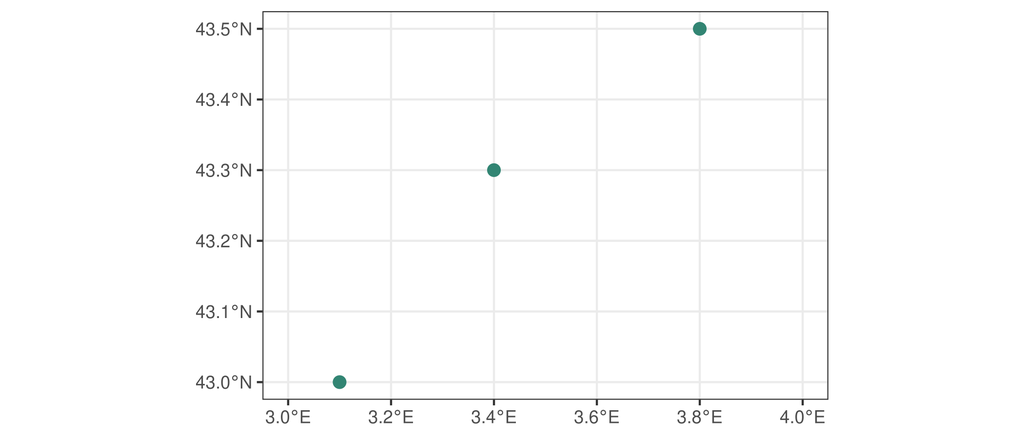

Three boring points

Now I use the `rnaturalearth{}` package to get a nice coastline map. This turned out to be the cause of the warning, so I set its `relation_to_geometry` attribute to be `"constant"`, and this magically gets rid of the problem. There is some explanation of this in [the sf vignette](https://r-spatial.github.io/sf/articles/sf1.html#how-attributes-relate-to-geometries%22) but it’s not exactly easy to follow. When reading it, I figured I’d need to set `agr` to `"constant"` instead of `NA` on the data and the crop box too, but that turned out to be unnecessary.

```r
# Coastline geometry from rnaturalearth
coastlines <- ne_coastline(scale = 50, returnclass = "sf") %>%
  # Get rid of the annoying warning from st_crop about
  # attributes assumed constant
  st_set_agr("constant")
```

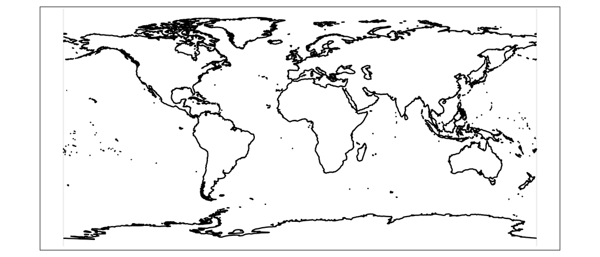

This is the map `rnaturalearth::ne_coastline()` generates at scale 50

This is the medium resolution map. It’s a vector graphic, so you can zoom in by cropping it without it degrading, although if you zoom in too far, it gets a bit pointy. There is a higher resolution version, but you need to install `rnaturalearthhires` for that, and currently for me, on R 4.1.2, that only works with `remotes::install_github()`.

Now I need to create a box to crop the map to. In my real data, I have thousands of different point locations on some of the maps I’m generating, while others have only one. I initially thought I’d create a box around the data with `st_bbox()`, but that doesn’t work if you only have a single location. I could put a buffer around each point, and put a box around that. That would be just fine for these three points, but it’s computationally expensive when there are a lot of points. So what I’m actually doing is creating an sf object with only two points, one at the minimum latitude and longitude, and one at the maximum.

```r
# Minmax dataset to crop map
minmax_sf <- tibble(
  Latitude = range(species_df$Latitude),
  Longitude = range(species_df$Longitude)
) %>%
  st_as_sf(coords = c("Longitude", "Latitude"),
           crs = st_crs(4326))
```

Now I create my crop box, by putting a buffer around the two points, so instead of them being points they are now circles. The buffer is specified in metres, and I’d rather have specified it in degrees, [but that doesn’t seem to be working optimally](https://github.com/r-spatial/sf/issues/1692).

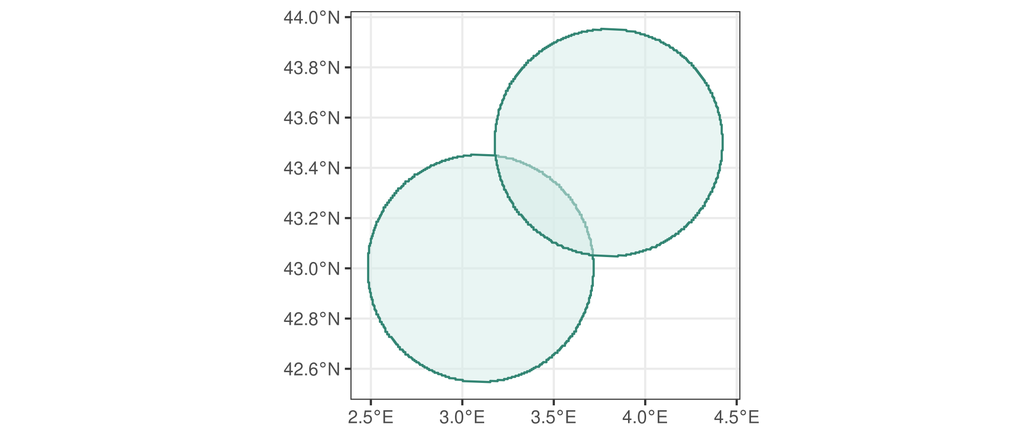

These points are now pretty big circles

```r
# Cropped map
buffered_sf <- minmax_sf %>%
    # Apply buffer to minmax points (in metres)
    st_buffer(dist = 50000)
```

Clearly drawing a box around these will make for a better map.

```r
# Cropped map
coast_crop_sf <- buffered_sf %>%
    # Draw box around buffer
    st_bbox(crs = st_crs(species_sf)) %>%
    # Crop to box - look!  No warnings!
    st_crop(coastlines, .)
```

Now let’s project the data onto the map. There is some finicking because I wanted nicely spaced breaks, and `scales::breaks_extended()` wasn’t working for axis ticks generated via `geom_sf()`.

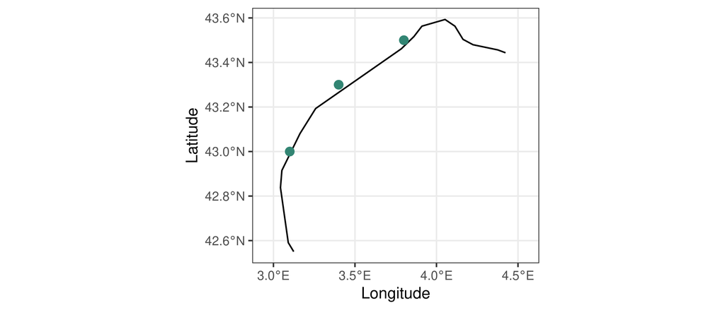

A map where I can see clearly that all my points are on the coast

```r
# For adjusting axis limits to get pretty breaks
# Extract the coordinates from the geometry, into columns X and Y
limits_df <- st_coordinates(coast_crop_sf) %>%
  # Didn't want a matrix
  as_tibble() %>%
  # Two rows, first one min, second max
  summarise(across(c(X, Y), range)) %>%
  # Round to nearest 0.5 for pleasing breaks
  mutate(across(everything(), ~ round(2 * .x) * .5))

ggplot() +
  # Plot the map
  geom_sf(data = coast_crop_sf) +
  # Add the points
  geom_sf(data = species_sf, colour = "#328573", size = 2.5) +
  # Impose the same projection on the whole lot
  coord_sf(crs = st_crs(species_sf)) +
  # Gets me breaks starting at a multiple of 0.5, with separation 0.5
  expand_limits(x = c(limits_df$X - 0.05, limits_df$X + 0.05)) +
  labs(
    x = "Longitude",
    y = "Latitude"
  ) +
  theme_bw()
```